# Partial Least Squares Regression (PLSR) for Quantifying Coffee Adulteration: Spectral Preprocessing Using MSC, Savitzky-Golay, and First Derivative

Author

Derick Malavi

## Introduction

Coffee adulteration, such as blending premium Arabica with lower-cost Robusta, undermines quality and authenticity, posing significant challenges for consumers, producers, and regulators. High-dimensional spectroscopic data, encompassing the full spectrum, provides valuable insights for detecting such fraud. However, the large number of variables requires advanced techniques to effectively model the data without overfitting.

```r
# Load libraries
warning = FALSE
  suppressWarnings(suppressMessages({
  library(caret)
  library(GA)
  library(viridis)
  library(Boruta)
  library(ggplot2)
  library(dplyr)
  library(readxl)
  library(readr)
  library(pls)
  library(janitor)
  library(class)
  library(MLmetrics)
  library(MLeval)
  library(themis)
  library(ROSE)
  library(parallel)
  library(doParallel)
  library(foreach)
  library(pheatmap)
  library(mdatools)
  library(nnet)
  library(DMwR)
  library(e1071)
  library(knitr)
  library(pROC)
  library(gridExtra)
  library(FactoMineR)
  library(doSNOW)
  library(MASS)
  library(factoextra)
  library(kernlab)}))
```

## Prepare Data

```r
# Load data: msc_sg_1d spectra

hsi_msc_sg_1d <- read.csv("coffee_ground_msc_sg_1d.csv")

# Ensure we have the same number of dimensions and the range of our columns/covariates
dim(hsi_msc_sg_1d)
```

```
[1] 1469  229
```

```r
# Check a few column names
col_check <- colnames(hsi_msc_sg_1d[,c(1:6)])
col_check
```

```
[1] "sample_id"     "binary_class"  "three_class"   "adult_percent"
[5] "cal_val"       "X935.609985"
```

```r
# our response variable (adulteration percentage) is column 4
# The spectral values start from column # 6 -------> 229

# Convert the adulteration percentage to numeric for compatibility with ML
hsi_msc_sg_1d$adult_percent <- as.numeric(hsi_msc_sg_1d$adult_percent)
```

## Get the X and y variables

```r
X <- hsi_msc_sg_1d[,c(6:229)]
y <- hsi_msc_sg_1d[,4]

class(y) #Ensure y (target variable) is a numeric for regression
```

```
[1] "numeric"
```

## Visualize X

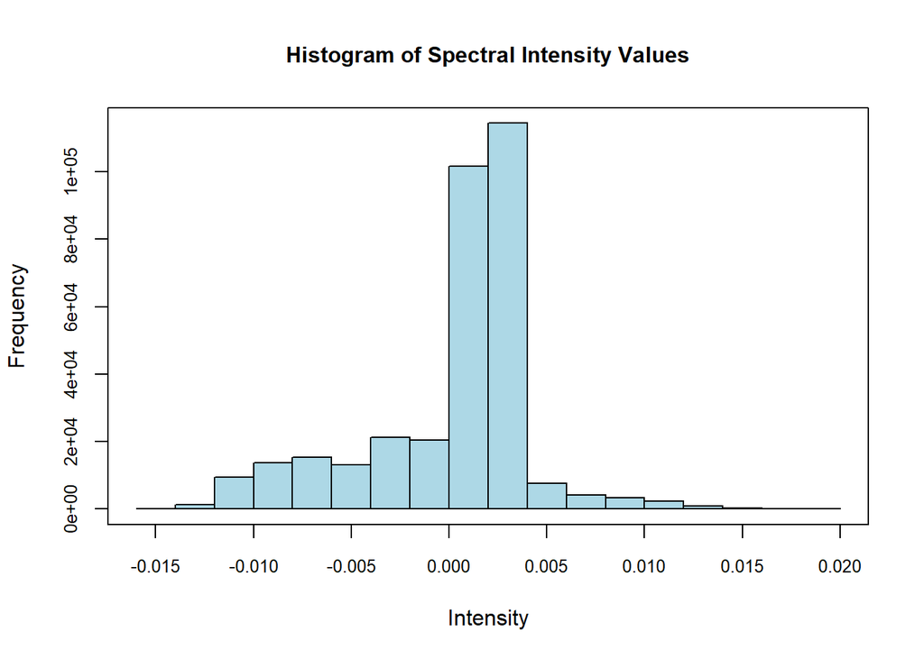

```r
hist(as.matrix(X), col = 'lightblue', cex.main = 1.0, cex.axis = 0.8,cex.lab = 1.0,
     main = 'Histogram of Spectral Intensity Values', xlab = 'Intensity'); box()
```

## Split the Data (Train_Test Split)

- We want to select features based on training data only to avoid any data leakage that could inflate model performance and make the model less generalizable to unseen data.

```r
# Subset samples for cross-validation and external validation (70/30)
# Record 1 under cal_val variable is for calibration while 2 will be for testing the model

sample<-hsi_msc_sg_1d$cal_val == 1

# Split to train and test sets
X_train <- X[sample,]
X_test <- X[!sample,]
y_train <-y[sample]
y_test <- y[!sample]

# Check length of the subsets for training and validation
dim(X_train)
```

```
[1] 1055  224
```

```r
dim(X_test)
```

```
[1] 414 224
```

```r
length(y_train)
```

```
[1] 1055
```

```r
length(y_test)
```

```
[1] 414
```

```r
# Merge the test and train data
train_data <- data.frame(y_train, X_train)
test_data <- data.frame(y_test, X_test)
```

## Check correlations by HeatMaps

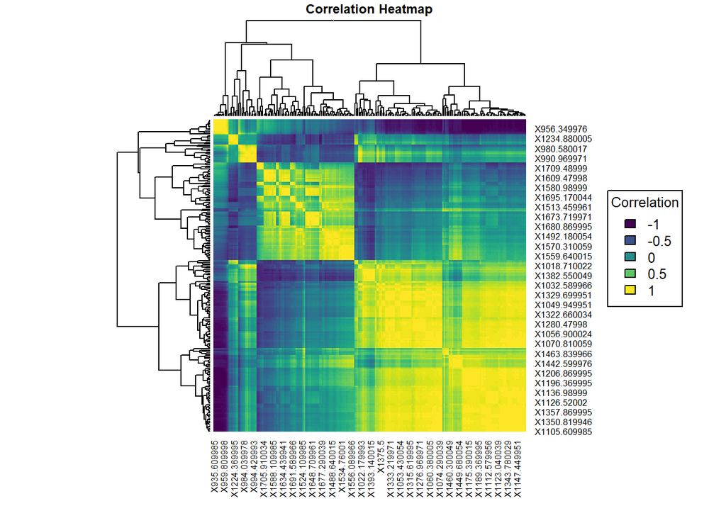

```r
#Calculate correlations
corr <- cor(train_data[,-1])

# Create a heat map
par(cex.main = 0.6)
heatmap(corr, symm = TRUE,
        col = viridis(50),
        main = "Correlation Heatmap")

# Add legend
legend("right",
       legend = seq(-1, 1, by = 0.5),  # Correlation range
       fill = viridis(5),
       title = "Correlation", cex = 0.8)
```

## Train Models

- We will train models based all spectral features

```r
# Set random seed for reproducibility
set.seed (123)

# Set up the training control(10 folds 10 times cross_validation)
control <- trainControl(method = "repeatedcv", number = 10, repeats = 10,
                        savePredictions = "final",
                        summaryFunction = defaultSummary,
                        selectionFunction = 'best', allowParallel = TRUE)

# We used oneSE for classification. For regression, we will use 'best': a model that minimizes RMSECV
```

```r
#Set the metric as accuracy
metric<-"RMSE"
```

```r
# Hyperparameter Tuning
# We will use tune Length to automatically determine the optimal number of PLS components
```

```r
set.seed(123)
#Register cluster for caret to train the models in parallel
cl<-makeCluster(6,type = "SOCK")
suppressWarnings(suppressMessages(
  registerDoSNOW(cl)))

# Start_time
start_time<-Sys.time()

#Train the model using cross-validation (10 folds, 10 times)
fit_pls_msc_sg_1d<-train(y = train_data[,1],
                         x = train_data[,-1],
                         method = 'pls', tuneLength = 50,
                         trControl = control,
                         metric = metric)
#End_time
end_time<-Sys.time()

model_training_time<-end_time-start_time

stopCluster(cl) # Stop the parallel run cluster

print(model_training_time)
```

```
Time difference of 14.21137 secs
```

```r
# Display regression results
print(fit_pls_msc_sg_1d)
```

```
Partial Least Squares

1055 samples
 224 predictor

No pre-processing
Resampling: Cross-Validated (10 fold, repeated 10 times)
Summary of sample sizes: 949, 949, 949, 948, 949, 950, ...
Resampling results across tuning parameters:

  ncomp  RMSE       Rsquared   MAE
   1     21.459250  0.4457154  17.251860
   2     17.635382  0.6255001  13.576125
   3     12.878818  0.8009901  10.193703
   4     12.223570  0.8209785   9.706621
```

[output cut: 49 more lines]

## Save the models for future use

```r
saveRDS(fit_pls_msc_sg_1d, "fit_pls_msc_sg_1d.rds")
```

## Plot the cross-validation results —–> Model Selection

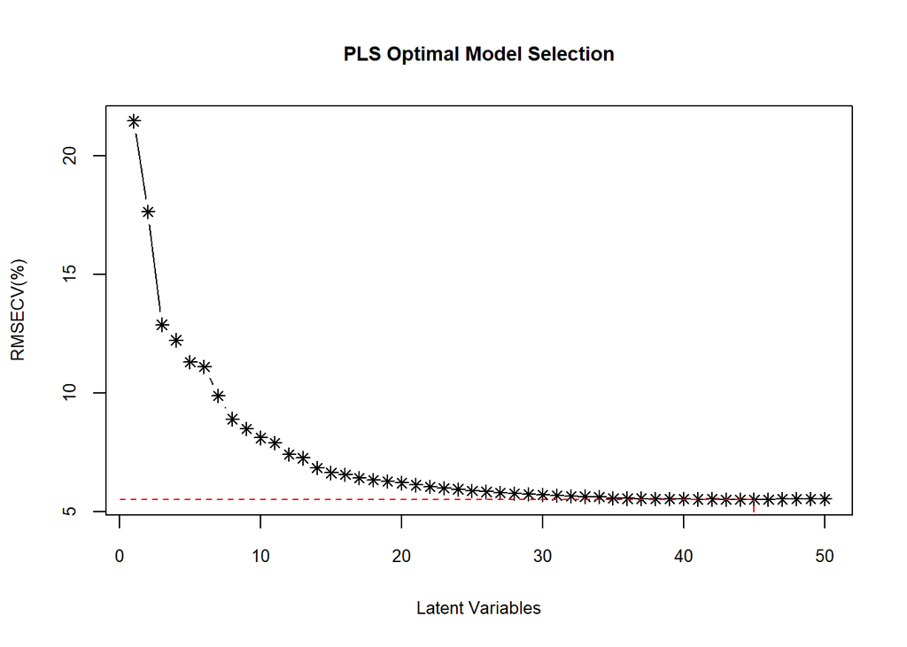

```r
# Imbalanced Data
pls_data <- fit_pls_msc_sg_1d$results
best_Lvs = fit_pls_msc_sg_1d$bestTune$ncomp
y_RMSE = pls_data$RMSE[pls_data$ncomp == best_Lvs]
plot(pls_data$ncomp,pls_data$RMSE, type = "b",col = "black",pch = 8,cex.axis = 0.8,
     xlab = "Latent Variables", ylab = "RMSECV(%)",cex.lab = 0.9,
     main = 'PLS Optimal Model Selection',
     cex.main = 0.9,
     cex.lab = 0.8)
# Add line from x-axis to the specific point
segments(x0 = best_Lvs, y0 = 0, x1 = best_Lvs, y1 = y_RMSE, col = "red", lty = 2)

# Add line from y-axis to the specific point
segments(x0 = 0, y0 = y_RMSE, x1 = best_Lvs, y1 = y_RMSE, col = "red", lty = 2)
```

## Display the cross-validation results

```r
print(paste('The optimal parameters for training the pls model is',
            fit_pls_msc_sg_1d$bestTune$ncomp, 'components'))
```

```
[1] "The optimal parameters for training the pls model is 45 components"
```

## Display CV Results in Tables

```r
kable(fit_pls_msc_sg_1d$results)
```

| ncomp | RMSE | Rsquared | MAE | RMSESD | RsquaredSD | MAESD |
| --- | --- | --- | --- | --- | --- | --- |
| 1 | 21.459250 | 0.4457154 | 17.251860 | 1.1082677 | 0.0552022 | 1.1012637 |
| 2 | 17.635382 | 0.6255001 | 13.576125 | 1.5850793 | 0.0611927 | 0.8434852 |
| 3 | 12.878818 | 0.8009901 | 10.193703 | 1.1305862 | 0.0327192 | 0.7240721 |
| 4 | 12.223570 | 0.8209785 | 9.706621 | 0.8651873 | 0.0235524 | 0.6836958 |
| 5 | 11.309192 | 0.8465156 | 8.847162 | 0.9563057 | 0.0243945 | 0.6585104 |
| 6 | 11.101332 | 0.8522132 | 8.663866 | 0.9356917 | 0.0236512 | 0.6558870 |
| 7 | 9.875336 | 0.8833350 | 7.765769 | 0.7269511 | 0.0162624 | 0.5640988 |
| 8 | 8.902751 | 0.9055626 | 7.004128 | 0.6227445 | 0.0125492 | 0.4859299 |
| 9 | 8.496812 | 0.9141276 | 6.712810 | 0.5790462 | 0.0109561 | 0.4592084 |
| 10 | 8.110673 | 0.9217448 | 6.385291 | 0.5295461 | 0.0095586 | 0.4561235 |
| 11 | 7.889290 | 0.9258919 | 6.284865 | 0.5246895 | 0.0090533 | 0.4471796 |
| 12 | 7.404668 | 0.9346977 | 5.905176 | 0.5052536 | 0.0081648 | 0.4225437 |
| 13 | 7.257631 | 0.9372525 | 5.761684 | 0.5017896 | 0.0081213 | 0.4162850 |
| 14 | 6.850024 | 0.9441560 | 5.533270 | 0.4969629 | 0.0078744 | 0.3995279 |
| 15 | 6.630812 | 0.9476745 | 5.284290 | 0.4807578 | 0.0071567 | 0.3828505 |
| 16 | 6.551196 | 0.9488986 | 5.199548 | 0.4415434 | 0.0066734 | 0.3503882 |
| 17 | 6.424771 | 0.9508572 | 5.111387 | 0.3890092 | 0.0059879 | 0.3263716 |
| 18 | 6.329472 | 0.9523078 | 5.000350 | 0.3910896 | 0.0058050 | 0.3263191 |
| 19 | 6.278631 | 0.9530764 | 4.952638 | 0.4061941 | 0.0060154 | 0.3358874 |
| 20 | 6.204983 | 0.9540947 | 4.912479 | 0.4113836 | 0.0060863 | 0.3345717 |
| 21 | 6.123151 | 0.9553393 | 4.846963 | 0.4159058 | 0.0060504 | 0.3512529 |
| 22 | 6.043487 | 0.9565201 | 4.773037 | 0.4135686 | 0.0059048 | 0.3521271 |
| 23 | 5.993101 | 0.9572717 | 4.726734 | 0.4029265 | 0.0057899 | 0.3426528 |
| 24 | 5.943230 | 0.9579899 | 4.665310 | 0.3841602 | 0.0055721 | 0.3283608 |
| 25 | 5.882218 | 0.9589004 | 4.639962 | 0.3882871 | 0.0055319 | 0.3303010 |
| 26 | 5.836141 | 0.9595276 | 4.632328 | 0.3864018 | 0.0054634 | 0.3290000 |
| 27 | 5.795441 | 0.9600870 | 4.601246 | 0.3790248 | 0.0053932 | 0.3320654 |
| 28 | 5.762615 | 0.9605484 | 4.566664 | 0.3618438 | 0.0050883 | 0.3051603 |
| 29 | 5.737432 | 0.9608954 | 4.527362 | 0.3623845 | 0.0049974 | 0.2984693 |
| 30 | 5.709213 | 0.9613014 | 4.505605 | 0.3634051 | 0.0049639 | 0.3049713 |
| 31 | 5.677487 | 0.9617503 | 4.492829 | 0.3501373 | 0.0048089 | 0.2987496 |
| 32 | 5.652491 | 0.9620876 | 4.460989 | 0.3645071 | 0.0049672 | 0.3058268 |
| 33 | 5.636109 | 0.9623040 | 4.455979 | 0.3603643 | 0.0049716 | 0.2958325 |
| 34 | 5.620021 | 0.9625390 | 4.455391 | 0.3524454 | 0.0048333 | 0.2908499 |
| 35 | 5.570009 | 0.9632245 | 4.432722 | 0.3514731 | 0.0047444 | 0.2899175 |
| 36 | 5.556225 | 0.9633795 | 4.425427 | 0.3438356 | 0.0046011 | 0.2802753 |
| 37 | 5.549790 | 0.9634779 | 4.427491 | 0.3361370 | 0.0044798 | 0.2720485 |
| 38 | 5.545533 | 0.9635403 | 4.430320 | 0.3266436 | 0.0043884 | 0.2651357 |
| 39 | 5.537395 | 0.9636491 | 4.436769 | 0.3290517 | 0.0044308 | 0.2743053 |
| 40 | 5.537637 | 0.9636565 | 4.432573 | 0.3340122 | 0.0044788 | 0.2767309 |
| 41 | 5.522113 | 0.9638640 | 4.414383 | 0.3340468 | 0.0044870 | 0.2760473 |
| 42 | 5.526151 | 0.9638123 | 4.421691 | 0.3337511 | 0.0044885 | 0.2725132 |
| 43 | 5.510984 | 0.9640208 | 4.413931 | 0.3274749 | 0.0044171 | 0.2661473 |
| 44 | 5.505860 | 0.9640770 | 4.405036 | 0.3277452 | 0.0044499 | 0.2637453 |
| 45 | 5.503282 | 0.9640995 | 4.412354 | 0.3287683 | 0.0044691 | 0.2630457 |
| 46 | 5.515433 | 0.9639439 | 4.422701 | 0.3244537 | 0.0044469 | 0.2605531 |
| 47 | 5.523852 | 0.9638354 | 4.423445 | 0.3202566 | 0.0043934 | 0.2569512 |
| 48 | 5.528702 | 0.9637846 | 4.432843 | 0.3192441 | 0.0043753 | 0.2521241 |
| 49 | 5.539779 | 0.9636424 | 4.445094 | 0.3141540 | 0.0043261 | 0.2477983 |
| 50 | 5.542812 | 0.9636041 | 4.438735 | 0.3189030 | 0.0044072 | 0.2495881 |

```r
# Select row for the optimal model
opt_row <- fit_pls_msc_sg_1d$results %>%
  filter(ncomp==fit_pls_msc_sg_1d$bestTune$ncomp)

kable(opt_row)
```

| ncomp | RMSE | Rsquared | MAE | RMSESD | RsquaredSD | MAESD |
| --- | --- | --- | --- | --- | --- | --- |
| 45 | 5.503282 | 0.9640995 | 4.412354 | 0.3287683 | 0.0044691 | 0.2630457 |

## Test the model performance on test data

```r
#Predict on the test set
observed <- test_data$y_test
predictions <- predict(fit_pls_msc_sg_1d,newdata=test_data)

# Generate predictions
results <- postResample(predictions, observed)

print(results)
```

```
     RMSE  Rsquared       MAE
8.8512085 0.9165557 7.1686309
```

```r
RMSEP = results[[1]]
R2 = results[[2]]
MAE = results[[3]]

cat('The RMSEP for the model on external validation is:', RMSEP,'\n')
```

```
The RMSEP for the model on external validation is: 8.851208
```

```r
cat('The R Squared value for the model is:', R2,'\n')
```

```
The R Squared value for the model is: 0.9165557
```

```r
# Calculate Residual Predictive Deviation to check model performance

RPD = sd(observed)/RMSEP

print(paste('The RPD values for the model is', round(RPD,2)))
```

```
[1] "The RPD values for the model is 3.29"
```

## Visualizations

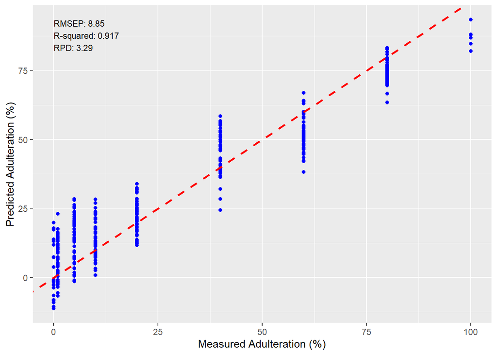

```r
# predicted vs observed line and scatter
# Create a data frame
results_df <- data.frame(observed=observed, predictions=predictions)

results_df %>%
  ggplot(aes(x = observed, y = predictions)) +
  geom_point(color = "blue") +
  geom_abline(slope = 1, intercept = 0, color = "red",
              linetype = "dashed", linewidth = 1) +
  labs( x = "Measured Adulteration (%)",
    y = "Predicted Adulteration (%)") +
  annotate("text",
    x = min(observed), y = max(predictions),
    label = paste("RMSEP:", round(RMSEP, 2),
      "\nR-squared:", round(R2, 3),
      "\nRPD:", round(RPD, 2)),
    hjust = 0, vjust = 1, size = 3, color = "black") +
  theme(
    axis.title = element_text(color = "black", size = 10),
    axis.text = element_text(color = "black"))+
  theme_gray()
```

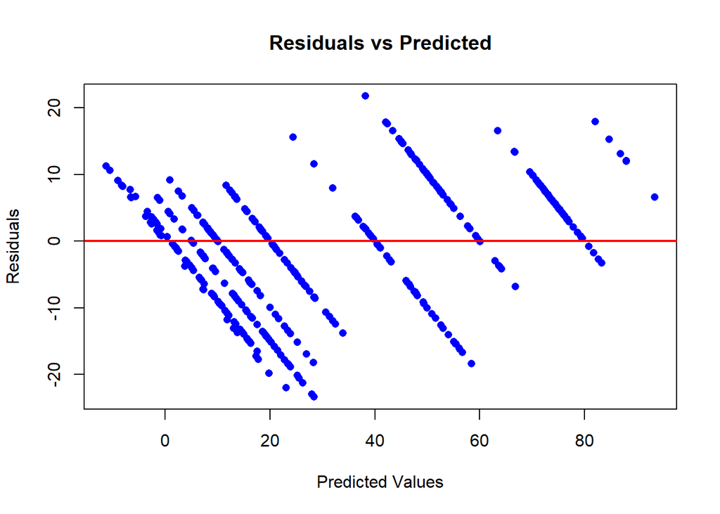

```r
# Check residuals

residuals <- observed - predictions

# Plot Residuals
plot(predictions, residuals,
     xlab = "Predicted Values",
     ylab = "Residuals",
     main = "Residuals vs Predicted",
     pch = 16, col = "blue")
abline(h = 0, col = "red", lwd = 2)
```

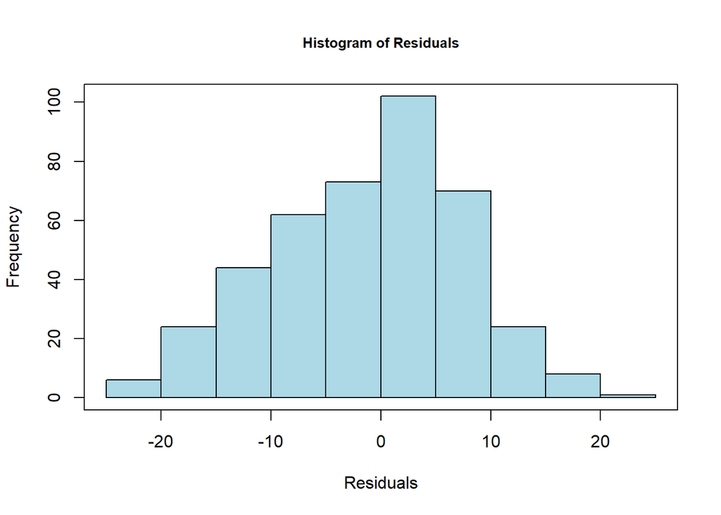

```r
hist(residuals,
     main = "Histogram of Residuals",
     xlab = "Residuals", cex.main = 0.8,
     col = "lightblue", border = "black"); box()
```

## Conclusion

- PLS demonstrate good performance in predicting adulteration in ground coffee. The model achieves an RPD value of 3.3.